# Bike share analysis

2024-02-08

IMPORTING REQUIRED PACKAGES

EXPLORING DATA

1. Preview data

For the exploratory steps, We will work with the dataframe hour as it is complete and contain hour details. We store it as data.

```r
head(data)
```

```
##             date_time instant     dteday season yr mnth hr holiday weekday
## 1 2011-01-01 00:00:00       1 2011-01-01      1  0    1  0       0       6
## 2 2011-01-01 01:00:00       2 2011-01-01      1  0    1  1       0       6
## 3 2011-01-01 02:00:00       3 2011-01-01      1  0    1  2       0       6
## 4 2011-01-01 03:00:00       4 2011-01-01      1  0    1  3       0       6
## 5 2011-01-01 04:00:00       5 2011-01-01      1  0    1  4       0       6
## 6 2011-01-01 05:00:00       6 2011-01-01      1  0    1  5       0       6
##   workingday weathersit temp  atemp  hum windspeed casual registered cnt
## 1          0          1 0.24 0.2879 0.81    0.0000      3         13  16
## 2          0          1 0.22 0.2727 0.80    0.0000      8         32  40
## 3          0          1 0.22 0.2727 0.80    0.0000      5         27  32
## 4          0          1 0.24 0.2879 0.75    0.0000      3         10  13
## 5          0          1 0.24 0.2879 0.75    0.0000      0          1   1
## 6          0          2 0.24 0.2576 0.75    0.0896      0          1   1
```

2.Overview of data characteristics

```r
nrow(data)
```

```
## [1] 17379
```

```r
colSums(is.na(data))
```

```
##  date_time    instant     dteday     season         yr       mnth         hr
##          0          0          0          0          0          0          0
##    holiday    weekday workingday weathersit       temp      atemp        hum
##          0          0          0          0          0          0          0
##  windspeed     casual registered        cnt
##          0          0          0          0
```

```r
data[duplicated(data),]
```

```
##  [1] date_time  instant    dteday     season     yr         mnth
##  [7] hr         holiday    weekday    workingday weathersit temp
## [13] atemp      hum        windspeed  casual     registered cnt
## <0 lignes> (ou 'row.names' de longueur nulle)
```

```r
colnames(data)
```

```
##  [1] "date_time"  "instant"    "dteday"     "season"     "yr"
##  [6] "mnth"       "hr"         "holiday"    "weekday"    "workingday"
## [11] "weathersit" "temp"       "atemp"      "hum"        "windspeed"
## [16] "casual"     "registered" "cnt"
```

```r
str(data)
```

```
## 'data.frame':    17379 obs. of  18 variables:
##  $ date_time : POSIXct, format: "2011-01-01 00:00:00" "2011-01-01 01:00:00" ...
##  $ instant   : int  1 2 3 4 5 6 7 8 9 10 ...
##  $ dteday    : chr  "2011-01-01" "2011-01-01" "2011-01-01" "2011-01-01" ...
##  $ season    : int  1 1 1 1 1 1 1 1 1 1 ...
##  $ yr        : int  0 0 0 0 0 0 0 0 0 0 ...
##  $ mnth      : int  1 1 1 1 1 1 1 1 1 1 ...
##  $ hr        : int  0 1 2 3 4 5 6 7 8 9 ...
##  $ holiday   : int  0 0 0 0 0 0 0 0 0 0 ...
##  $ weekday   : int  6 6 6 6 6 6 6 6 6 6 ...
##  $ workingday: int  0 0 0 0 0 0 0 0 0 0 ...
##  $ weathersit: int  1 1 1 1 1 2 1 1 1 1 ...
##  $ temp      : num  0.24 0.22 0.22 0.24 0.24 0.24 0.22 0.2 0.24 0.32 ...
##  $ atemp     : num  0.288 0.273 0.273 0.288 0.288 ...
##  $ hum       : num  0.81 0.8 0.8 0.75 0.75 0.75 0.8 0.86 0.75 0.76 ...
##  $ windspeed : num  0 0 0 0 0 0.0896 0 0 0 0 ...
##  $ casual    : int  3 8 5 3 0 0 2 1 1 8 ...
##  $ registered: int  13 32 27 10 1 1 0 2 7 6 ...
##  $ cnt       : int  16 40 32 13 1 1 2 3 8 14 ...
```

3. Converting data type

```r
str(data)
```

```
## 'data.frame':    17379 obs. of  18 variables:
##  $ date_time : POSIXct, format: "2011-01-01 00:00:00" "2011-01-01 01:00:00" ...
##  $ instant   : int  1 2 3 4 5 6 7 8 9 10 ...
##  $ dteday    : Date, format: "2011-01-01" "2011-01-01" ...
##  $ season    : Factor w/ 4 levels "1","2","3","4": 1 1 1 1 1 1 1 1 1 1 ...
##  $ yr        : Factor w/ 2 levels "0","1": 1 1 1 1 1 1 1 1 1 1 ...
##  $ mnth      : Factor w/ 12 levels "1","2","3","4",..: 1 1 1 1 1 1 1 1 1 1 ...
##  $ hr        : int  0 1 2 3 4 5 6 7 8 9 ...
##  $ holiday   : Factor w/ 2 levels "0","1": 1 1 1 1 1 1 1 1 1 1 ...
##  $ weekday   : Factor w/ 7 levels "0","1","2","3",..: 7 7 7 7 7 7 7 7 7 7 ...
##  $ workingday: Factor w/ 2 levels "0","1": 1 1 1 1 1 1 1 1 1 1 ...
##  $ weathersit: Factor w/ 4 levels "1","2","3","4": 1 1 1 1 1 2 1 1 1 1 ...
##  $ temp      : num  0.24 0.22 0.22 0.24 0.24 0.24 0.22 0.2 0.24 0.32 ...
##  $ atemp     : num  0.288 0.273 0.273 0.288 0.288 ...
##  $ hum       : num  0.81 0.8 0.8 0.75 0.75 0.75 0.8 0.86 0.75 0.76 ...
##  $ windspeed : num  0 0 0 0 0 0.0896 0 0 0 0 ...
##  $ casual    : int  3 8 5 3 0 0 2 1 1 8 ...
##  $ registered: int  13 32 27 10 1 1 0 2 7 6 ...
##  $ cnt       : int  16 40 32 13 1 1 2 3 8 14 ...
```

4.Recoding data

```r
levels(data$season)
```

```
## [1] "Winter" "Spring" "Summer" "Fall"
```

```r
levels(data$mnth)
```

```
##  [1] "January"   "February"  "March"     "April"     "May"       "June"
##  [7] "July"      "August"    "September" "October"   "November"  "December"
```

```r
levels(data$weekday)
```

```
## [1] "Sunday"    "Monday"    "Tuesday"   "Wednesday" "Thursday"  "Friday"
## [7] "Saturday"
```

```r
levels(data$holiday)
```

```
## [1] "No"  "Yes"
```

5.Summary satistics

```r
summary(data)
```

```
##    date_time                         instant          dteday
##  Min.   :2011-01-01 00:00:00.00   Min.   :    1   Min.   :2011-01-01
##  1st Qu.:2011-07-04 22:30:00.00   1st Qu.: 4346   1st Qu.:2011-07-04
##  Median :2012-01-02 21:00:00.00   Median : 8690   Median :2012-01-02
##  Mean   :2012-01-02 15:41:22.85   Mean   : 8690   Mean   :2012-01-02
##  3rd Qu.:2012-07-02 06:30:00.00   3rd Qu.:13034   3rd Qu.:2012-07-02
##  Max.   :2012-12-31 23:00:00.00   Max.   :17379   Max.   :2012-12-31
##
##     season        yr             mnth            hr        holiday
##  Winter:4242   2011:8645   May     :1488   Min.   : 0.00   No :16879
##  Spring:4409   2012:8734   July    :1488   1st Qu.: 6.00   Yes:  500
##  Summer:4496               December:1483   Median :12.00
##  Fall  :4232               August  :1475   Mean   :11.55
##                            March   :1473   3rd Qu.:18.00
##                            October :1451   Max.   :23.00
##                            (Other) :8521
##       weekday     workingday                 weathersit         temp
##  Sunday   :2502   No : 5514   Clear               :11413   Min.   :0.020
##  Monday   :2479   Yes:11865   Mist+Cloudy         : 4544   1st Qu.:0.340
##  Tuesday  :2453               Light rain/Light Sow: 1419   Median :0.500
##  Wednesday:2475               Heavy rain/Snow     :    3   Mean   :0.497
##  Thursday :2471                                            3rd Qu.:0.660
##  Friday   :2487                                            Max.   :1.000
##  Saturday :2512
##      atemp             hum           windspeed          casual
##  Min.   :0.0000   Min.   :0.0000   Min.   :0.0000   Min.   :  0.00
##  1st Qu.:0.3333   1st Qu.:0.4800   1st Qu.:0.1045   1st Qu.:  4.00
##  Median :0.4848   Median :0.6300   Median :0.1940   Median : 17.00
##  Mean   :0.4758   Mean   :0.6272   Mean   :0.1901   Mean   : 35.68
##  3rd Qu.:0.6212   3rd Qu.:0.7800   3rd Qu.:0.2537   3rd Qu.: 48.00
##  Max.   :1.0000   Max.   :1.0000   Max.   :0.8507   Max.   :367.00
##
##    registered         cnt
##  Min.   :  0.0   Min.   :  1.0
##  1st Qu.: 34.0   1st Qu.: 40.0
##  Median :115.0   Median :142.0
##  Mean   :153.8   Mean   :189.5
##  3rd Qu.:220.0   3rd Qu.:281.0
##  Max.   :886.0   Max.   :977.0
##
```

6. Screening variables relationship The main variable we will study is cnt which represent the total rental bikes. It will represent our outcome that we want to forecast. We will make some cross tab to assess how our outcome (cnt) varies depending on the main features.

```r
data%>%
group_by(season)%>%
summarise(mean_cnt= mean(cnt))
```

```
## # A tibble: 4 × 2
##   season mean_cnt
##   <fct>     <dbl>
## 1 Winter     111.
## 2 Spring     208.
## 3 Summer     236.
## 4 Fall       199.
```

We can notice that summer seems to be the best moment of of the year for bike renting.

```r
data %>%
group_by(workingday)%>%
summarise(mean_cnt = mean(cnt))
```

```
## # A tibble: 2 × 2
##   workingday mean_cnt
##   <fct>         <dbl>
## 1 No             181.
## 2 Yes            193.
```

We can also notice that mean bike usage is greater during working day.

```r
data %>%
group_by(hr)%>%
summarise(mean_cnt = mean(cnt))%>%
print(n=23)
```

```
## # A tibble: 24 × 2
##       hr mean_cnt
##    <int>    <dbl>
##  1     0    53.9
##  2     1    33.4
##  3     2    22.9
##  4     3    11.7
##  5     4     6.35
##  6     5    19.9
##  7     6    76.0
##  8     7   212.
##  9     8   359.
## 10     9   219.
## 11    10   174.
## 12    11   208.
## 13    12   253.
## 14    13   254.
## 15    14   241.
## 16    15   251.
## 17    16   312.
## 18    17   461.
## 19    18   426.
## 20    19   312.
## 21    20   226.
## 22    21   172.
## 23    22   131.
## # ℹ 1 more row
```

Considering this table,the best hour for bike renting is noticed in the evening.

Number of bikers vs weather situation

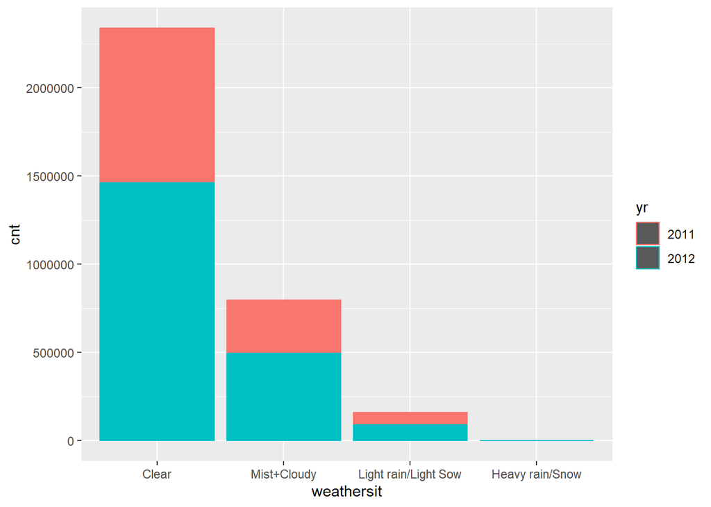

```r
i <- ggplot(data, aes(weathersit, cnt, color = yr))
i+geom_col()
```

Clear weather seems to be the best moment for bike renting.

Correlation between temperature and number of bikes

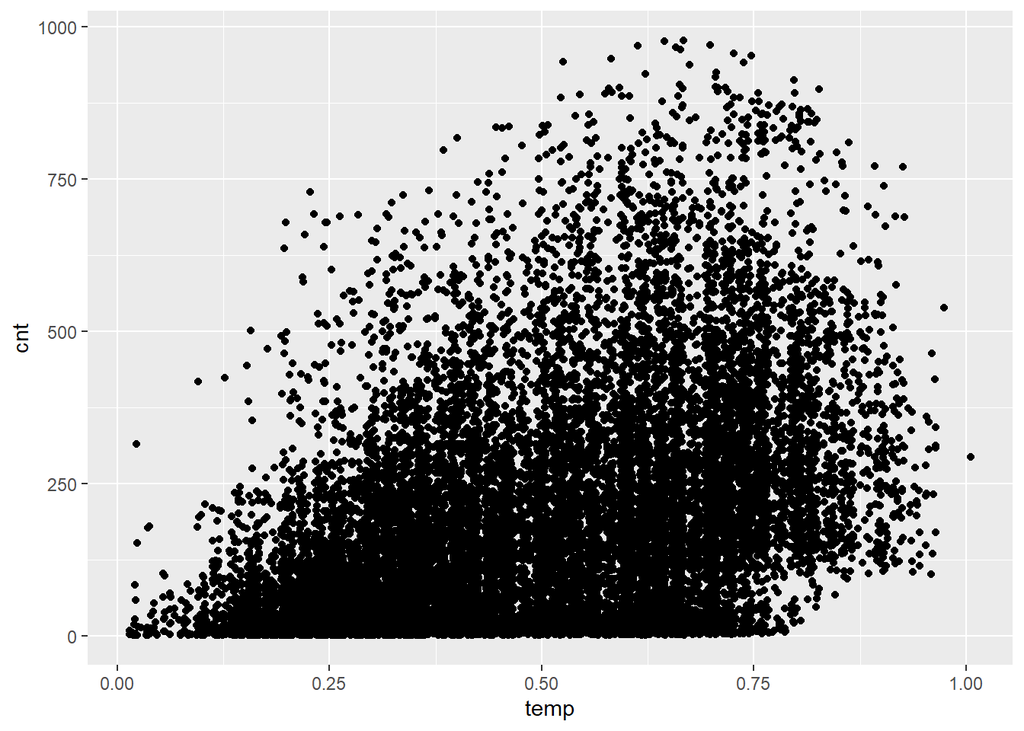

```r
i <- ggplot(data, aes(temp, cnt))
i+geom_jitter()
```

```r
cor(data$temp, data$cnt)
```

```
## [1] 0.4047723
```

The plot and the output of correlation value (0.4) shows there is probably a moderate positive correlation between normalized temperature and number of bikes

Number of bikers vs holiday

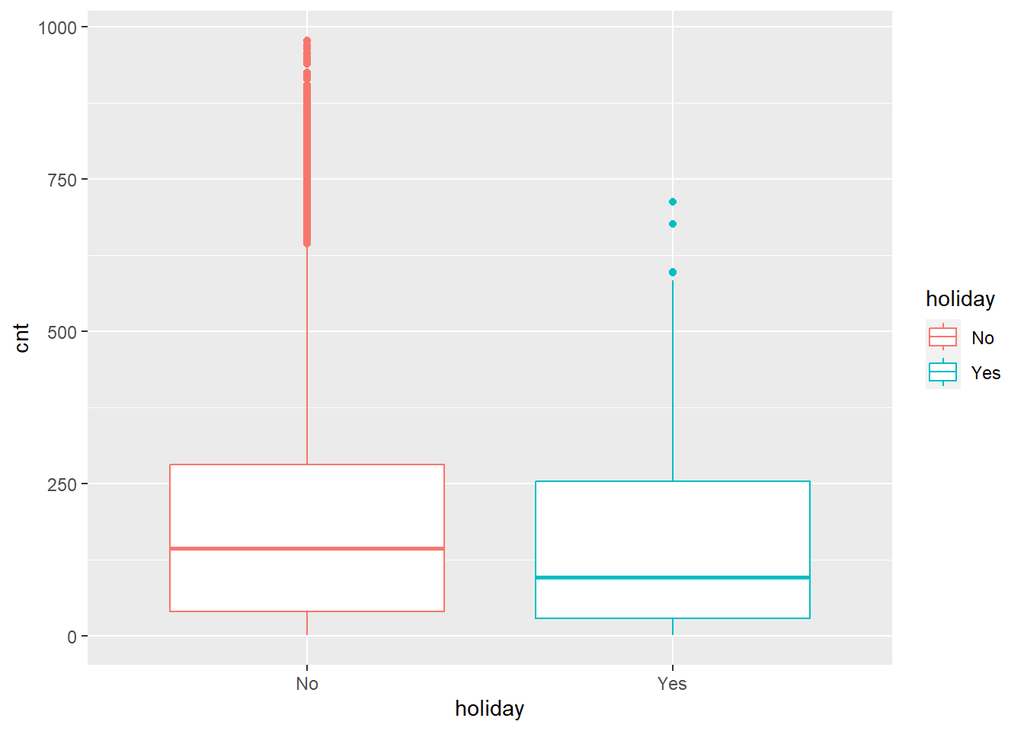

```r
i <- ggplot(data, aes(holiday, cnt, color = holiday))
i+geom_boxplot()
```

We can notice that we have on average less bike renting during holidays than other days.

Correlation matrice of number of bikes and other numeric features.

```r
data_num <- data[, c('temp', 'cnt', 'atemp', 'hum', 'windspeed')]
cor(data_num)
```

```
##                  temp         cnt       atemp         hum   windspeed
## temp       1.00000000  0.40477228  0.98767214 -0.06988139 -0.02312526
## cnt        0.40477228  1.00000000  0.40092930 -0.32291074  0.09323378
## atemp      0.98767214  0.40092930  1.00000000 -0.05191770 -0.06233604
## hum       -0.06988139 -0.32291074 -0.05191770  1.00000000 -0.29010490
## windspeed -0.02312526  0.09323378 -0.06233604 -0.29010490  1.00000000
```

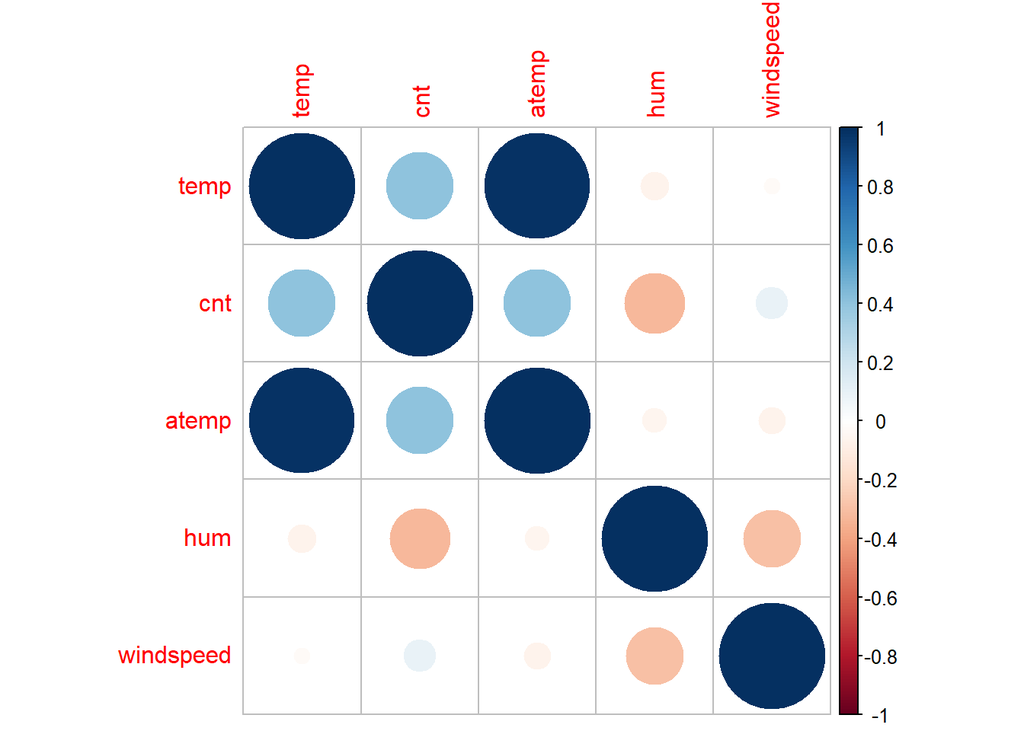

```r
corrplot(cor(data_num))
```

We can notice that there is moderate positive correlation between number of bikes and varibale temp(temperature) and atemp(feeling temperature). Humidity appears to be negatively correlated with number of bikes.

INTERACTIVE TIME SERIES PLOTS

```r
graph
```

[interactive chart not shown]

SMOOTHEN TIMESERIES DATA To smoothen timeseries data, we will work with daily data and apply a moving average of 15 days period. Notice also that for the rest of our analysis, this daily data will be used for forecasting.Indeed, in this type of business, predicting daily bike renting seems to be more relevant for management purpose.

1. Removing outliers
2. Smoothing data

```r
head(data)
```

```
##   instant     dteday season yr mnth holiday weekday workingday weathersit
## 1       1 2011-01-01      1  0    1       0       6          0          2
## 2       2 2011-01-02      1  0    1       0       0          0          2
## 3       3 2011-01-03      1  0    1       0       1          1          1
## 4       4 2011-01-04      1  0    1       0       2          1          1
## 5       5 2011-01-05      1  0    1       0       3          1          1
## 6       6 2011-01-06      1  0    1       0       4          1          1
##       temp    atemp      hum windspeed casual registered  cnt moving_average
## 1 0.344167 0.363625 0.805833 0.1604460    331        654  985             NA
## 2 0.363478 0.353739 0.696087 0.2485390    131        670  801             NA
## 3 0.196364 0.189405 0.437273 0.2483090    120       1229 1349             NA
## 4 0.200000 0.212122 0.590435 0.1602960    108       1454 1562             NA
## 5 0.226957 0.229270 0.436957 0.1869000     82       1518 1600             NA
## 6 0.204348 0.233209 0.518261 0.0895652     88       1518 1606             NA
```

2. Graph of smoothen data

```r
graph
```

[interactive chart not shown]

CHECKING IF DATA IS STATIONARY

Stationary is important as its guarantee the feasibility of some statisical tests. Indeed, most of parametric analysis require that statistical properties(mean, variance, covariance) do not change over time.

```r
Box.test(tsData)
```

```
##
##  Box-Pierce test
##
## data:  tsData
## X-squared = 523.41, df = 1, p-value < 2.2e-16
```

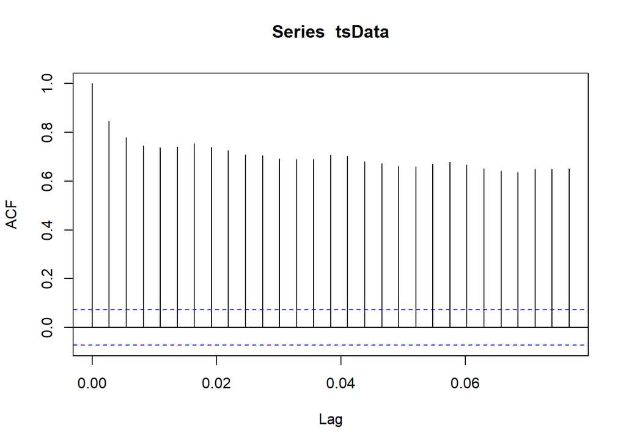

```r
acf(tsData)
```

```r
summary(ur.kpss(tsData))
```

```
##
## #######################
## # KPSS Unit Root Test #
## #######################
##
## Test is of type: mu with 6 lags.
##
## Value of test-statistic is: 5.5176
##
## Critical value for a significance level of:
##                 10pct  5pct 2.5pct  1pct
## critical values 0.347 0.463  0.574 0.739
```

Our p-value of box test is less than 0.05 (p-value < 2.2e-16). In a similar vein, ACF values are above the confidence interval. We can conclude that data are non stationary. The KPSS test also confirmed that our data is non stationary as the test result (5.5176) is much higher than critical values.

DECOMPOSE TIME SERIES DATA

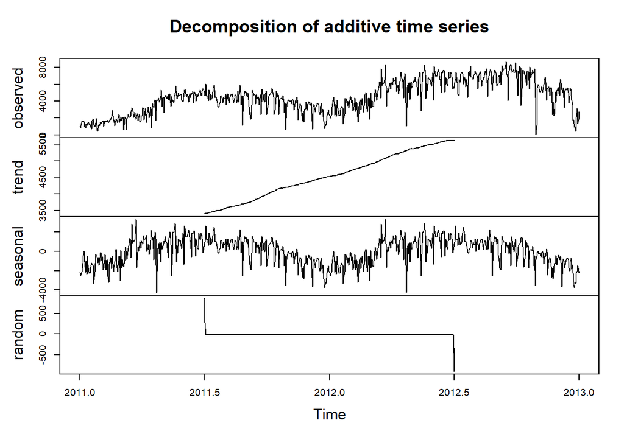

```r
plot(comp)
```

Decomposition shows that the trend is slightly upward and the noise is negligible. Seasonal components capture the entire series plot. Therefore we will include an seasonal differencing once building our forecasting model.

BUILDING AN AUTOARIMA MODEL FOR FORECASTING

```r
comp$trend <- na.omit(comp$trend)
comp$seasonal <- na.omit(comp$seasonal)
```

```r
length(ts_train)
```

```
## [1] 584
```

```r
length(ts_test)
```

```
## [1] 147
```

1. Autoarima model

AUTO ARIMA is suitable for non stationary and seasonal data. It will automatically compute differencing.

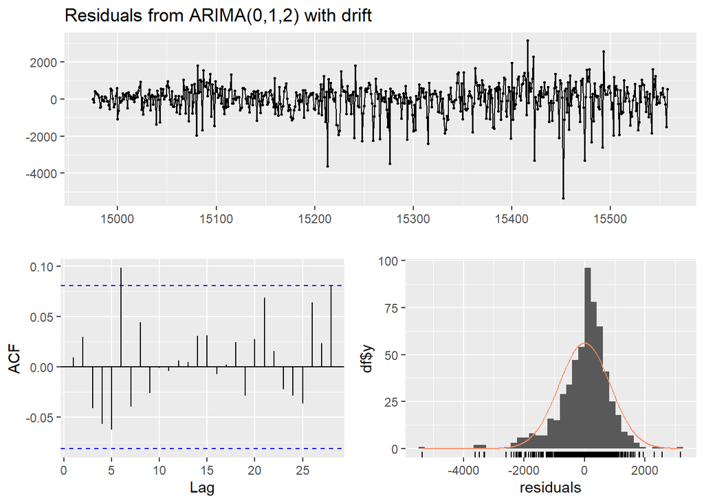

```
##
##  Ljung-Box test
##
## data:  Residuals from ARIMA(0,1,2) with drift
## Q* = 13.937, df = 8, p-value = 0.08342
##
## Model df: 2.   Total lags used: 10
```

```r
data_train <- data[train_start:train_end,]
model <- auto.arima(ts_train)
checkresiduals(model)
```

```r
shapiro.test(residuals(model))
```

```
##
##  Shapiro-Wilk normality test
##
## data:  residuals(model)
## W = 0.92811, p-value = 4.135e-16
```

Auto.arima residuals checking indicate that residual are not correlated but the distribution is skewed. Let’s try different ARIMA models.

2. ARIMA MODEL

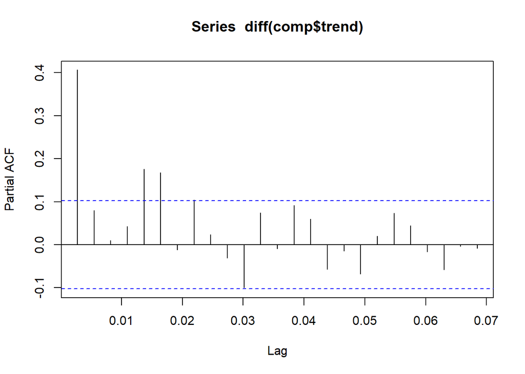

```r
pacf(diff(comp$trend))
```

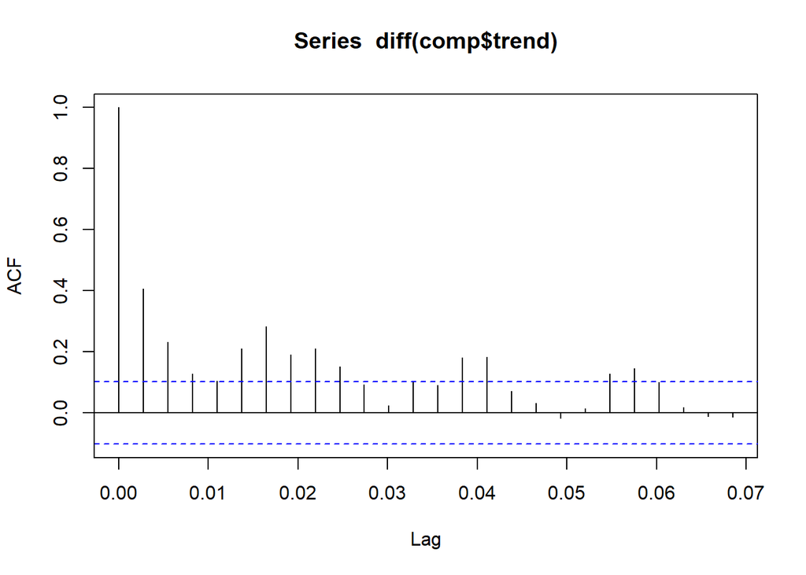

```r
acf(diff(comp$trend))
```

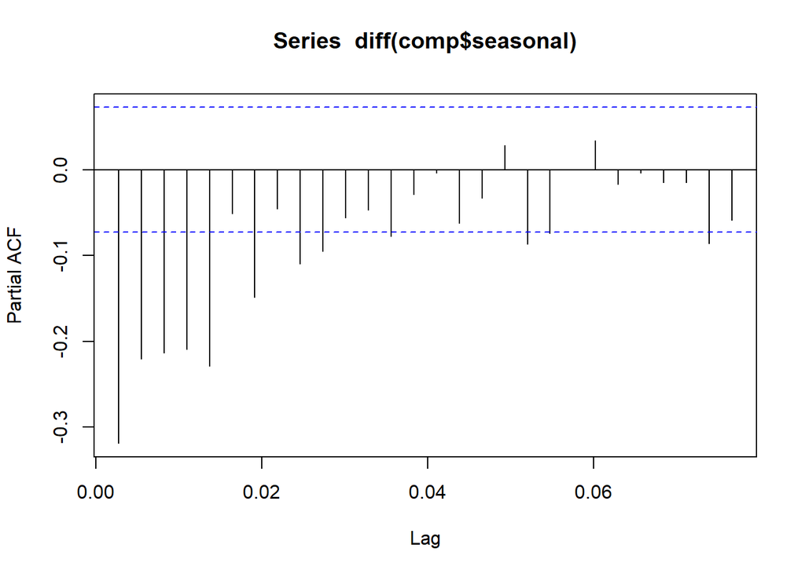

```r
pacf(diff(comp$seasonal))
```

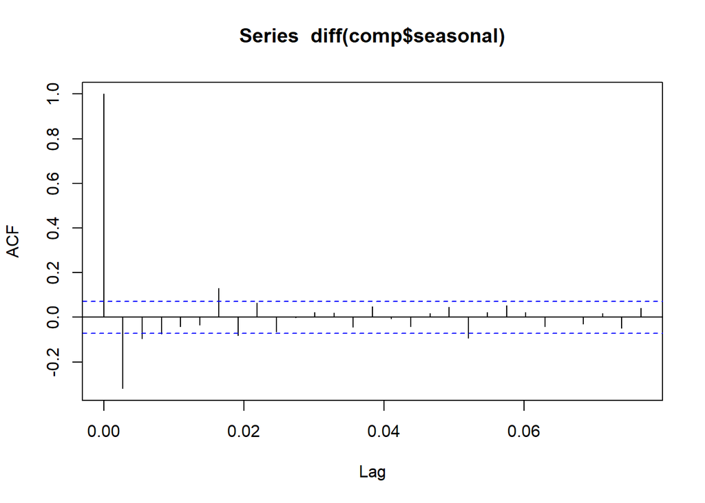

```r
acf(diff(comp$seasonal))
```

(0,0) and (0,3) are p,q order for the non seasonal part (4,0), (0,1), (4,1) are P,Q order for the seasonal compounds p refer to the number of lag for which pacf cut of (pacf of diff data) d = refer to degree of differencing q refer to the number of lag for which acf cut off

```
## [1] FALSE FALSE FALSE  TRUE FALSE FALSE
```

```
## [1] FALSE FALSE FALSE  TRUE
```

We screened the best order parameters then we also screened the best period parameters(monthly, quarterly, semestrially, and yearly)

The best model is : ARIMA_4_4 <- arima(ts_train, order=c(0,1,3),seasonal = list(order = c(0,1,1), period = 300), method =‘ML’)

3. Forecasting and Evaluating the model performance

```r
accuracy(forecasts, ts_test)
```

```
##                      ME     RMSE       MAE         MPE      MAPE      MASE
## Training set   1.678475  830.642  429.6731   -4.804196  12.79744 0.6205303
## Test set     338.359954 2167.695 1757.9310 -161.945293 190.86612 2.5387895
##                       ACF1 Theil's U
## Training set -0.0001331235        NA
## Test set      0.7021594425  3.277828
```

We can notice that the mean absolute error of our model is 429.6 in our training set and 1757.9 in our test set. When considering the Mean Average Percentage Error, it is reasonable on our training set(12.7%) but quite large in our test set (190.8). Our model perform quite good on our training set but is less perfomant on the test. Having data for a larger period of time will probably improve our forecast. We could also try other forecasting method.

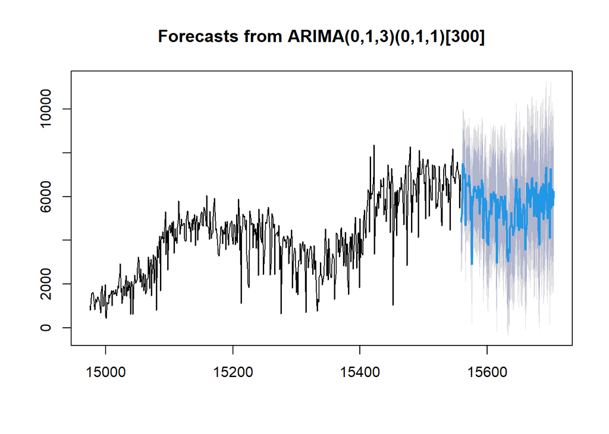

```r
plot(forecasts)
```